# Exploratory Data Analysis

STOR 320.02 Group 3

May 18, 2024

# Creator: Lillian Potter

### Q1: Are there any disparities in arrest rates based on race?

```r
arrests_by_race <- NC_stops %>%
group_by(subject_race) %>%
  filter(subject_race %in% c("asian/pacific islander","black","white","hispanic")) %>%
  summarize(arrest_rate=mean(outcome=="arrest",na.rm=TRUE))

arrests_by_race
```

```
## # A tibble: 4 × 2
##   subject_race           arrest_rate
##   <chr>                        <dbl>
## 1 asian/pacific islander      0.0157
## 2 black                       0.0353
## 3 hispanic                    0.0526
## 4 white                       0.0219
```

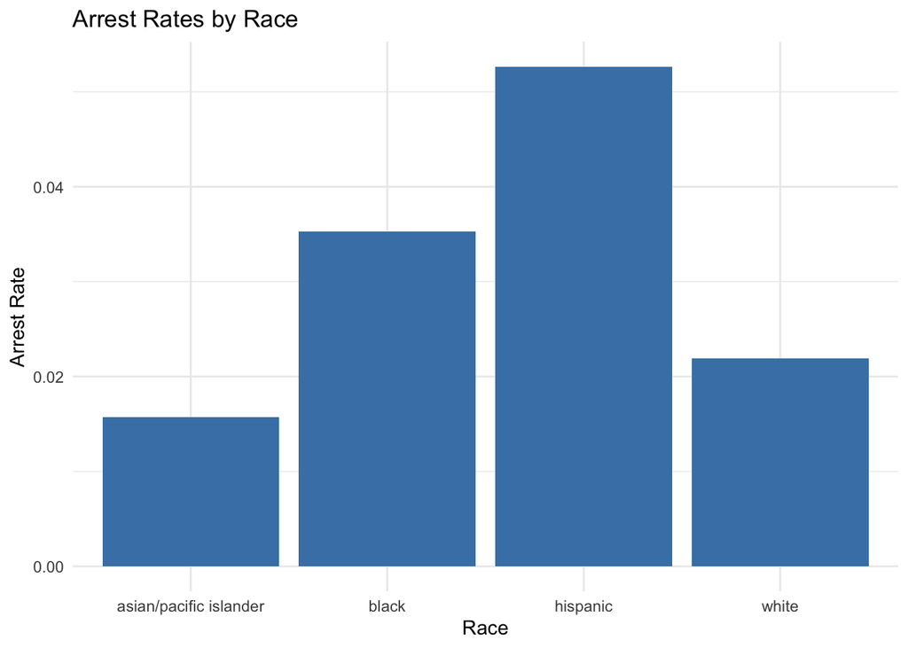

```r
ggplot(arrests_by_race, aes(x = subject_race, y = arrest_rate)) +
  geom_bar(stat = "identity", fill = "steelblue") +
  labs(title = "Arrest Rates by Race",
       x = "Race",
       y = "Arrest Rate") +
  theme_minimal()
```

### Q2: Are there any disparities in arrest rates based on sex?

```r
arrests_by_sex <- NC_stops %>%
  group_by(subject_sex) %>%
  filter(subject_sex %in% c("male","female")) %>%
  summarize(arrest_rate=mean(outcome=="arrest",na.rm=TRUE))

arrests_by_sex
```

```
## # A tibble: 2 × 2
##   subject_sex arrest_rate
##   <chr>             <dbl>
## 1 female           0.0148
## 2 male             0.0409
```

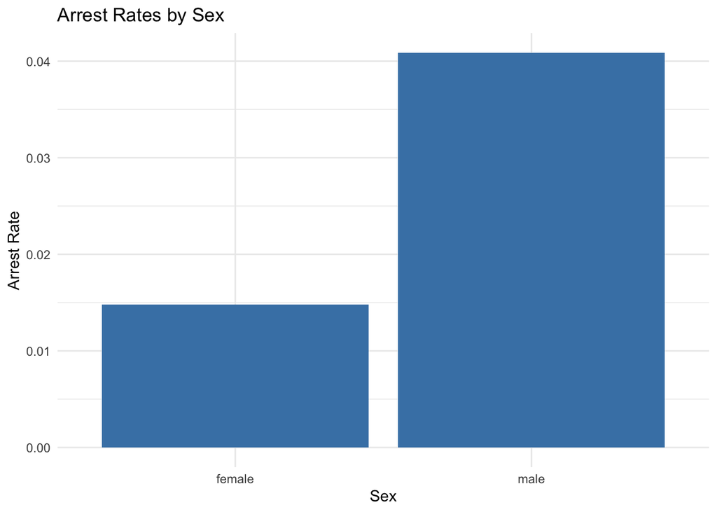

```r
ggplot(arrests_by_sex, aes(x = subject_sex, y = arrest_rate)) +
  geom_bar(stat = "identity", fill = "steelblue") +
  labs(title = "Arrest Rates by Sex",
       x = "Sex",
       y = "Arrest Rate") +
  theme_minimal()
```

# Interpreter: Rodrigo Pires

### Q1: After getting stopped, what identifiers (race, gender, age) get searched the most?

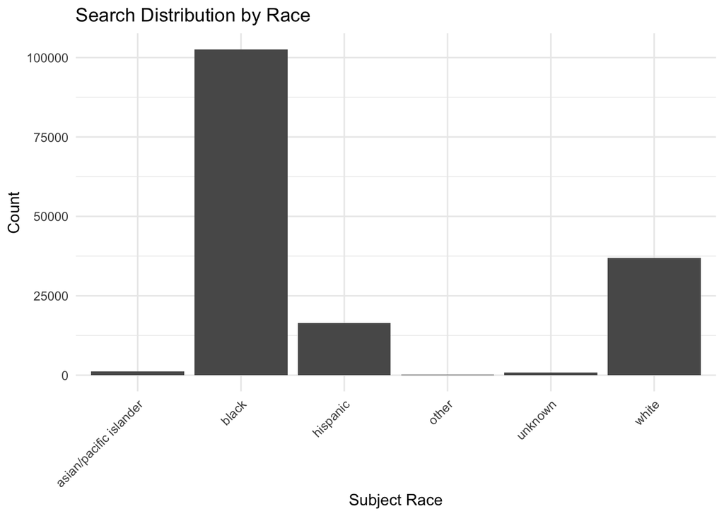

```r
filtered_search <- NC_stops %>%
  filter(search_conducted == TRUE)

# Plot for Race
ggplot(filtered_search, aes(x = subject_race)) +
  geom_bar() +
  labs(title = "Search Distribution by Race",
       x = "Subject Race",
       y = "Count") +
  theme_minimal() +
  theme(axis.text.x = element_text(angle = 45, hjust = 1))
```

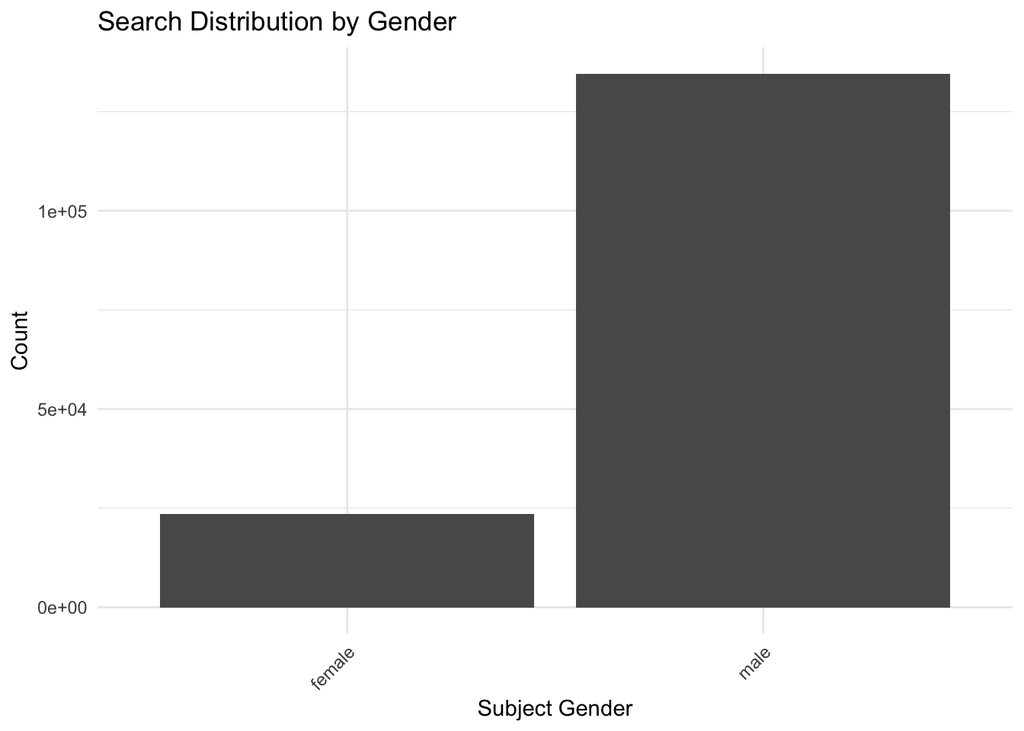

```r
# Plot for Gender
ggplot(filtered_search, aes(x = subject_sex)) +
  geom_bar() +
  labs(title = "Search Distribution by Gender",
       x = "Subject Gender",
       y = "Count") +
  theme_minimal() +
  theme(axis.text.x = element_text(angle = 45, hjust = 1))
```

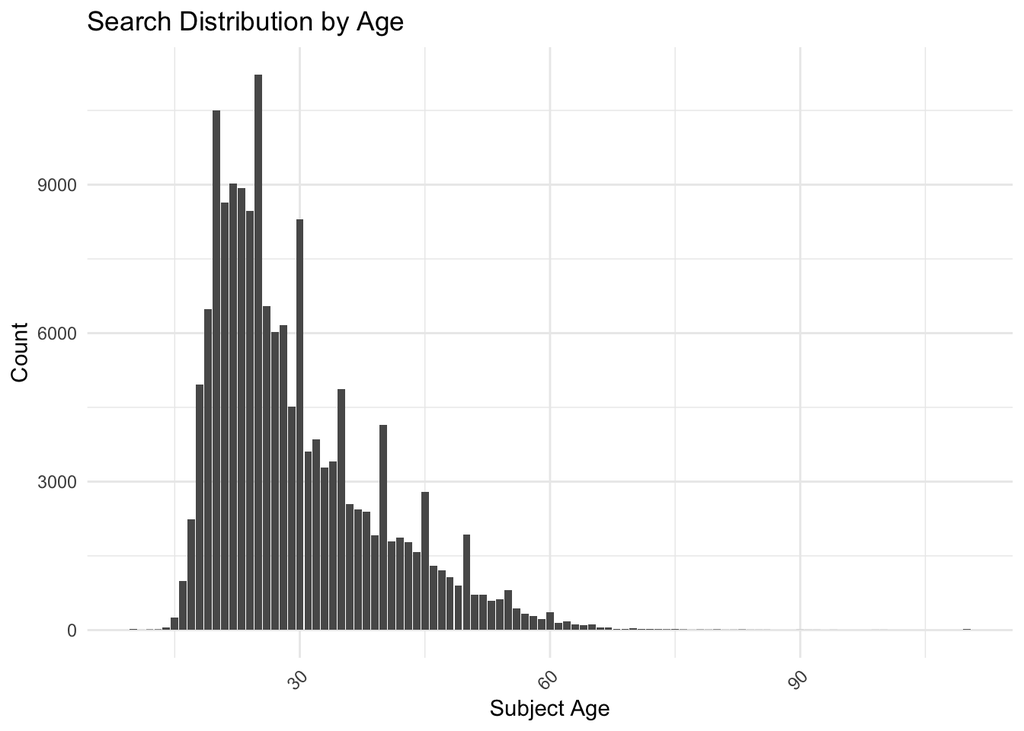

```r
# Plot for Age
ggplot(filtered_search, aes(x = subject_age)) +
  geom_bar() +
  labs(title = "Search Distribution by Age",
       x = "Subject Age",
       y = "Count") +
  theme_minimal() +
  theme(axis.text.x = element_text(angle = 45, hjust = 1))
```

### Q2: Are there differences in outcomes for the different reasons for getting stopped?

```r
filtered_outcomes <- NC_stops %>%
  select('reason_for_stop', 'outcome')

filtered_outcomes
```

```
## # A tibble: 3,054,884 × 2
##    reason_for_stop               outcome
##    <chr>                         <chr>
##  1 Safe Movement Violation       warning
##  2 Vehicle Regulatory Violation  citation
##  3 Vehicle Equipment Violation   citation
##  4 Vehicle Regulatory Violation  citation
##  5 Safe Movement Violation       warning
##  6 Other Motor Vehicle Violation warning
##  7 Vehicle Regulatory Violation  citation
##  8 Stop Light/Sign Violation     warning
##  9 Stop Light/Sign Violation     warning
## 10 Stop Light/Sign Violation     warning
## # ℹ 3,054,874 more rows
```

```r
result <- filtered_outcomes %>%
  group_by(reason_for_stop, outcome) %>%
  summarise(count = n()) %>%
  group_by(reason_for_stop) %>%
  mutate(proportion = count / sum(count))
```

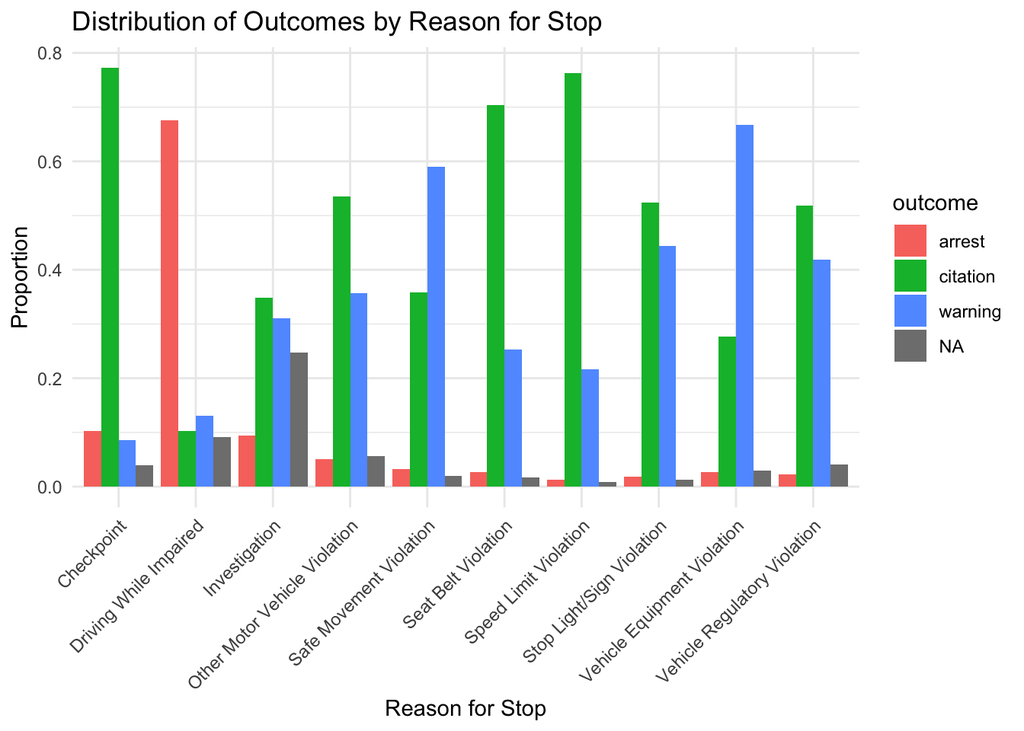

```r
ggplot(result, aes(x = reason_for_stop, y = proportion, fill = outcome)) +
  geom_bar(stat = "identity", position = "dodge") +
  labs(title = "Distribution of Outcomes by Reason for Stop",
       x = "Reason for Stop",
       y = "Proportion") +
  theme_minimal() +
  theme(axis.text.x = element_text(angle = 45, hjust = 1))
```

# Orator #1: Keaton Crooks

### Q1: Are there certain months of the year or days of the month when police stops are higher?

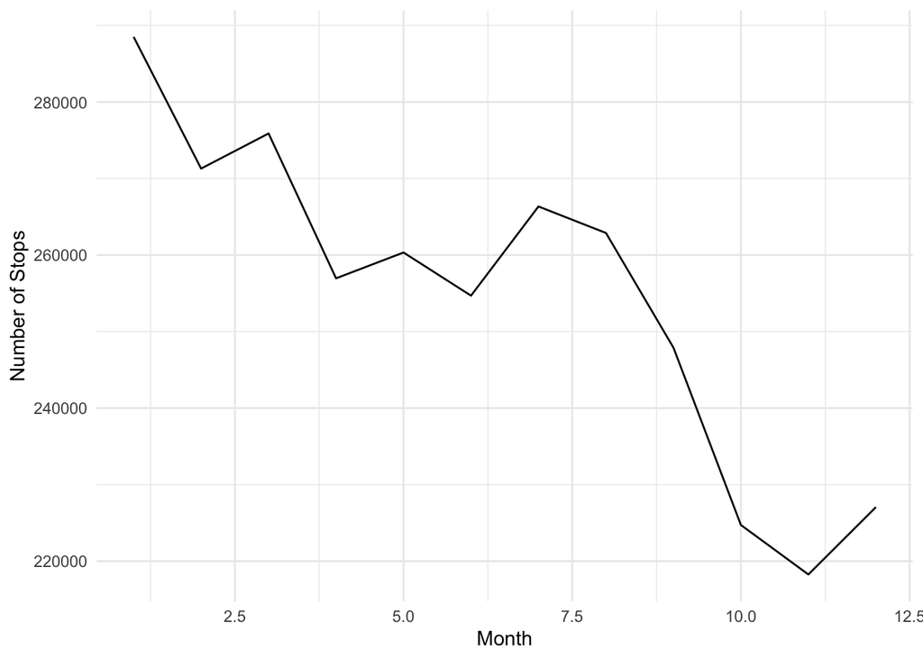

```r
NC_stops1 = NC_stops %>%
  separate(date,into=c("Year","Month","Day"),sep="-") %>%
  mutate_at(2:4,as.numeric)

NC_stopplot = NC_stops1 %>%
  group_by(Month) %>%
  summarize(n = n()) %>%
  ggplot(mapping = aes(x = Month, y = n)) + geom_line() + theme_minimal() +ylab("Number of Stops")

NC_stopplot
```

### Q2: After getting stopped, what identifiers (race/gender) are most likely to get let off with just a warning?

```r
StopsNA = NC_stops[!is.na(NC_stops$subject_race),]
StopsNA = StopsNA[!is.na(StopsNA$subject_sex),]
pergroup = matrix(NA, nrow = length(unique(StopsNA$subject_sex)), ncol = length(unique(StopsNA$subject_race)))
unique_race = unique(NC_stops$subject_race )
unique_sex = unique(NC_stops$subject_sex )
for(j in unique(StopsNA$subject_sex)){
  for(k in unique(StopsNA$subject_race)){
    rs = filter(StopsNA, subject_race==k, subject_sex == j)
    warning = filter(rs, outcome == "warning")
    percent = nrow(warning) / nrow(rs)
    pergroup[which(unique(StopsNA$subject_sex)==j), which(unique(StopsNA$subject_race)==k)] <- percent
  }}
colnames(pergroup) <- c( "black", "white", "hispanic", "asian/pacific islander", "unknown", "other")
rownames(pergroup) <- c("female", "male")
pergroup
```

```
##            black     white  hispanic asian/pacific islander   unknown     other
## female 0.4008639 0.3285330 0.3748458              0.3948726 0.3433104 0.3704842
## male   0.4020611 0.2671646 0.3605748              0.3880519 0.3489247 0.3909383
```

# Orator #2: Eric Rash

### Q1: Do certain age groups get stopped for specific reasons more than others? (i.e. older demographic having more stop light violations)

```r
##groups by the age and reason for stops
age_reason_counts <- NC_stops %>%
  group_by(subject_age, reason_for_stop) %>%
  summarize(count = n()) %>%
  ungroup()
```

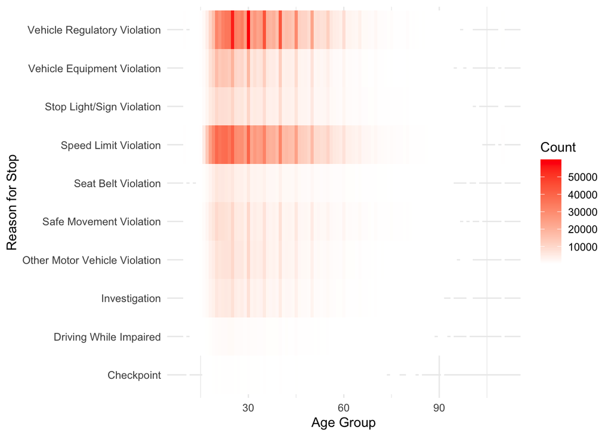

```r
##creates a heatmap that displays how often an age group is stopped for each reason
ggplot(age_reason_counts, aes(x = subject_age, y = reason_for_stop, fill = count)) +
  geom_tile() +
  scale_fill_gradient(low = "white", high = "red") +
  labs(
    x = "Age Group",
    y = "Reason for Stop",
    fill = "Count"
  ) +
  theme_minimal()
```

### Q2:How have arrest rates changed since 2001?

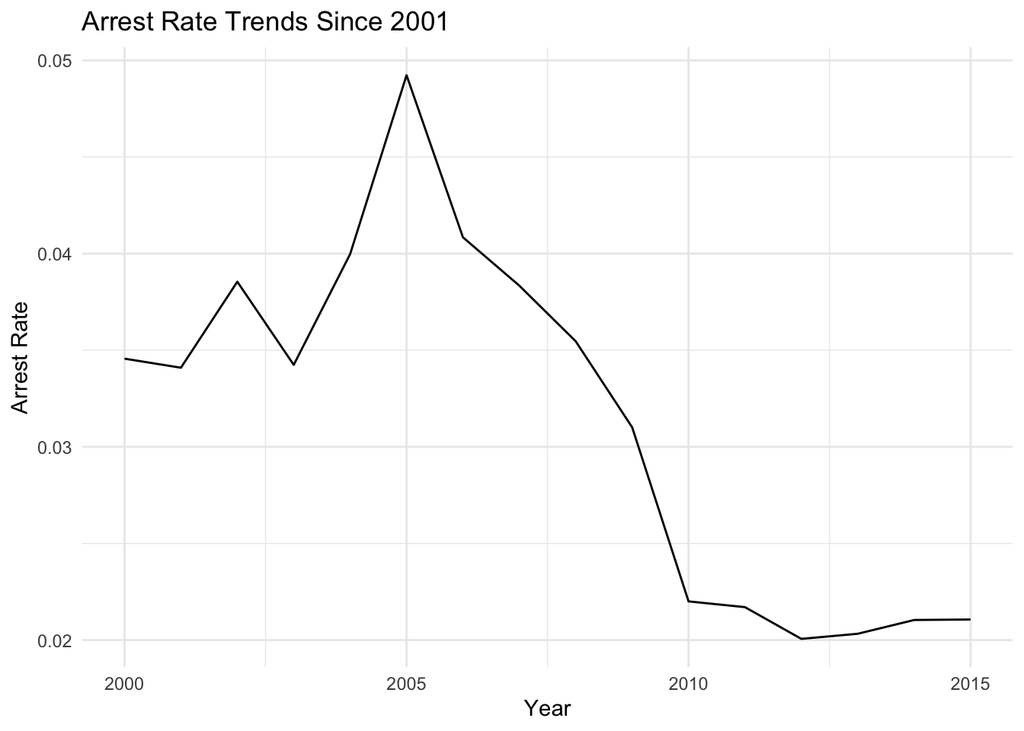

```r
## calculates arrest rates by year
arrest_rates <- NC_stops %>%
  mutate(year = lubridate::year(date)) %>%
  group_by(year) %>%
  summarise(
    total_stops = n(),
    total_arrests = sum(arrest_made == "TRUE"),
    arrest_rate = total_arrests / total_stops
  ) %>%
  ungroup()
##Returns a lineplot of arrest rates by year
ggplot(arrest_rates, aes(x = year, y = arrest_rate)) +
  geom_line() +
  labs(
    x = "Year",
    y = "Arrest Rate",
    title = "Arrest Rate Trends Since 2001"
  ) +
  theme_minimal()
```

# Deliverer: Joan Chan

### Q1: What is the likelihood of finding contraband after a search is done?

```r
filtered_data <- NC_stops %>% filter(search_conducted == TRUE)
search_and_contraband_counts <- table(filtered_data$search_conducted, filtered_data$contraband_found)
search_and_contraband_counts_df <- as.data.frame(search_and_contraband_counts)
colnames(search_and_contraband_counts_df) <- c("Search_Conducted", "No_Contraband", "Contraband_Found")
search_and_contraband_counts_df$Likelihood_Contraband_Found <-
  search_and_contraband_counts_df$Contraband_Found /
  (search_and_contraband_counts_df$Contraband_Found + search_and_contraband_counts_df$No_Contraband)
search_and_contraband_counts_df
```

```
##   Search_Conducted No_Contraband Contraband_Found Likelihood_Contraband_Found
## 1             TRUE         FALSE           120101                          NA
## 2             TRUE          TRUE            38007                          NA
```

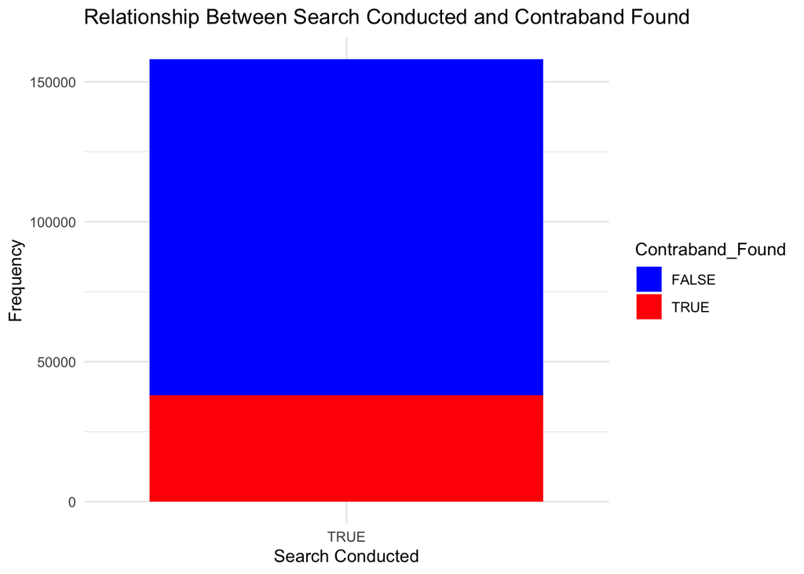

```r
data <- data.frame(
  Search_Conducted = c("TRUE", "TRUE"),
  Contraband_Found = c("FALSE", "TRUE"),
  Frequency = c(120101, 38007)
)
ggplot(data, aes(x = Search_Conducted, y = Frequency, fill = Contraband_Found)) +
  geom_bar(stat = "identity") +
  labs(x = "Search Conducted", y = "Frequency", title = "Relationship Between Search Conducted and Contraband Found") +
  scale_fill_manual(values = c("FALSE" = "blue", "TRUE" = "red")) +
  theme_minimal()
```

### Q2: Are there any disparities among each police department and their arrest rates?

```r
department_arrest_rates <- NC_stops %>%
  group_by(department_name) %>%
  summarize(
    total_stops = n(),
    arrest_count = sum(arrest_made == "TRUE"),
    arrest_prop = mean(arrest_made == "TRUE")
  ) %>%
  arrange(desc(arrest_prop))
department_arrest_rates
```

```
## # A tibble: 5 × 4
##   department_name                           total_stops arrest_count arrest_prop
##   <chr>                                           <int>        <int>       <dbl>
## 1 UNC Greensboro University Police Departm…       48057         2161      0.0450
## 2 Charlotte-Mecklenburg Police Department       1576998        54121      0.0343
## 3 Raleigh Police Department                      856400        23220      0.0271
## 4 UNC Charlotte University Police Departme…       21455          460      0.0214
## 5 Greensboro Police Department                   551974        11236      0.0204
```

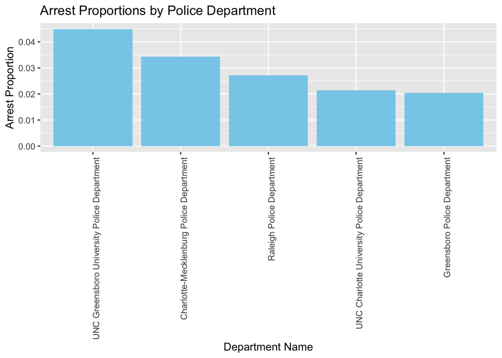

```r
ggplot(department_arrest_rates, aes(x = reorder(department_name, -arrest_prop), y = arrest_prop)) +
  geom_bar(stat = "identity", fill = "skyblue") +
  labs(x = "Department Name", y = "Arrest Proportion", title = "Arrest Proportions by Police Department") +
  theme(axis.text.x = element_text(angle = 90, hjust = 1))
```